# Advanced Social Networks Group Project

### University of Trento, 2021-2022

[figure not shown]

### Group Members

Mattolin Giulio, *224072*, giulio.mattolin@studenti.unitn.it

Paolazzi Elisa, *224424*, elisa.paolazzi-2@studenti.unitn.it

Passabì Daniele, *221229*, daniele.passabi@studenti.unitn.it

## 1. Drawing a network using R

You are provided with a unique Excel file (EXERCISE0XX.xls), which contains the directed network (Bullying sheet) capturing who bullies whom among a group of students in an Italian school class. The network was based on asking every person the question “Who do you bully?”.

You are also given a spreadsheet with attributes for each student (Attributes sheet). This included the attributes:

- The student’s gender (0 = female, 1 = male),
- The student’s grade (which goes from 0 to 10, with 10 being the highest grade),
- The student’s ethnicity, where:
  - 1 $\rightarrow$ born abroad with foreign parents (first generation immigrants),
  - 2 $\rightarrow$ born in Italy with foreign parents (second generation immigrants),
  - 3 $\rightarrow$ born in Italy with at least one Italian parent (which we label “Italian”)

#### **Point 1.1**

##### *Draw the network using the Fruchterman-Reingold layout with names (but without attributes).*

##### *Add the R script of how you obtained the drawings.*

```r
# Import libraries
library(openxlsx)   # open and read excel files
library(dplyr)      # data manipulation

# Import .xlsx file
bully_xlsx = read.xlsx("data/EXERCISE006.xlsx", sheet = "Bullying", colNames = TRUE)

# Fix the column types (from dbl to int)
bully_xlsx = bully_xlsx %>%
  mutate_if(is.numeric, as.integer)

# Set the first column as Row Index
bully_xlsx = data.frame(bully_xlsx[,-1], row.names = bully_xlsx[,1])

# Convert the data to a matrix
bully_matrix = as.matrix(bully_xlsx)

# Show first 9 nodes
bully_matrix[1:9,1:9]
```

```
##            Alessandro Andrea Angela Angelo Anna Aurora Flavio Francesco Gianna
## Alessandro          0      0      0      0    0      0      0         1      0
## Andrea              0      0      1      0    0      0      0         1      0
## Angela              0      0      0      0    1      0      0         0      1
## Angelo              0      1      0      0    0      1      0         0      0
## Anna                0      1      0      0    0      0      0         0      1
## Aurora              0      0      0      0    0      0      0         0      0
## Flavio              0      0      0      0    0      0      0         0      0
## Francesco           0      1      1      0    0      0      0         0      1
## Gianna              0      0      0      0    0      0      0         0      0
```

```r
library(sna)

# Convert the matrix into a "network object"
bully_network = as.network(bully_matrix, directed = TRUE)
bully_network
```

```
##  Network attributes:
##   vertices = 25
##   directed = TRUE
##   hyper = FALSE
##   loops = FALSE
##   multiple = FALSE
##   bipartite = FALSE
##   total edges= 74
##     missing edges= 0
##     non-missing edges= 74
##
##  Vertex attribute names:
##     vertex.names
##
## No edge attributes
```

The output of the function confirms that we are working with a *directed network* of *25 nodes*, with *74 total ties*.

It is a *one-mode network*, as we have only one type of nodes (students) and ties (who bullies whom).

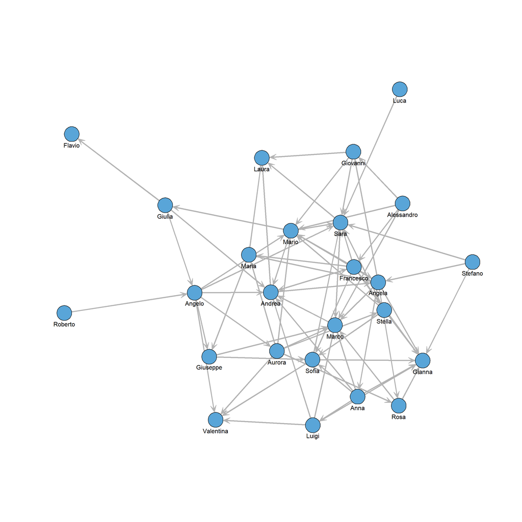

```r
# Plot the network
gplot(bully_network,
      gmode = "digraph",

      # layout
      mode = "fruchtermanreingold",
      jitter = F,

      # ties
      edge.col = "grey70",

      # nodes
      vertex.col = "#59A5D8",
      vertex.cex = 1,

      # arrow
      arrowhead.cex = 0.5,

      # labels
      displaylabels = T,
      label.pos = 1,
      label.cex = 1
      )
```

#### **Point 1.2**

##### *Next draw the network again using the Fruchterman-Reingold layout without names, but now with all 3 attributes (gender, grade and ethnicity) included using in some way a combination of color, shape and size of nodes.*

##### *Add the R script of how you obtained the drawings.*

```r
# Import .xlsx attributes data
attributes_xlsx = read.xlsx("data/EXERCISE006.xlsx", sheet = "Attributes", colNames = TRUE)
attributes_xlsx
```

|  | ID | Gender | Grade | Ethnicity |
| --- | --- | --- | --- | --- |
| 1 | Alessandro | 1 | 4 | 3 |
| 2 | Andrea | 1 | 8 | 1 |
| 3 | Angela | 0 | 5 | 2 |
| 4 | Angelo | 1 | 7 | 3 |
| 5 | Anna | 0 | 6 | 1 |
| 6 | Aurora | 0 | 7 | 3 |
| 7 | Flavio | 1 | 6 | 3 |
| 8 | Francesco | 1 | 5 | 1 |
| 9 | Gianna | 0 | 9 | 3 |
| 10 | Giovanni | 1 | 7 | 3 |

[output cut: 15 more lines]

We decide to display the attributes as follows:

- *color* represents **gender**
- *vertex shape* represents **ethnicity**
- *vertex size* represent **grade**

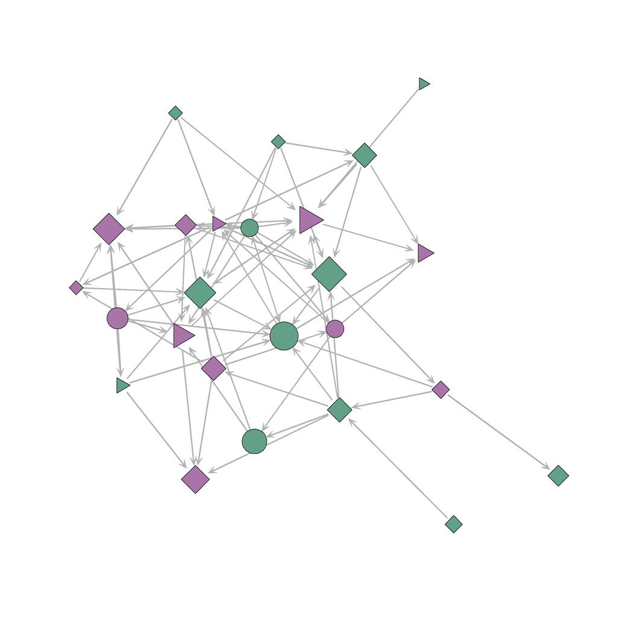

```r
# Prepare color vector for gender
genderVectorColor = c()
for (g in attributes_xlsx$Gender) {
  if (g == 1) {
    genderVectorColor = append(genderVectorColor, "#63A088")
  } else {
    genderVectorColor = append(genderVectorColor, "#A975A9")
  }
}

# Prepare color vector for ethnicity
ethnicityVectorColor = c()
for (e in attributes_xlsx$Ethnicity) {
  if (e == 1) {
    ethnicityVectorColor = append(ethnicityVectorColor, 50)
  } else if (e == 2) {
    ethnicityVectorColor = append(ethnicityVectorColor, 3)
  } else {
    ethnicityVectorColor = append(ethnicityVectorColor, 4)
  }
}

# Plot the network
plot = gplot(bully_network,
      gmode = "digraph",

      # layout
      mode = "fruchtermanreingold",
      jitter = T,

      # ties
      edge.col = "grey70",

      # nodes
      vertex.col = genderVectorColor,
      vertex.cex = attributes_xlsx$Grade/5, # size of the vectors represent grade value
      vertex.sides = ethnicityVectorColor,

      # arrow
      arrowhead.cex = 0.5,

      # labels
      displaylabels = F,
      label.pos = 1,
      label.cex = 1
      )
```

#### **Point 1.3**

##### *Create a legend for the attributes (this does not have to be with R, but needs to clarify how the different attributes were represented in the network).*

We can now plot the network with a customized legend indicating the attribute-color/shape/size combinations previously specified.

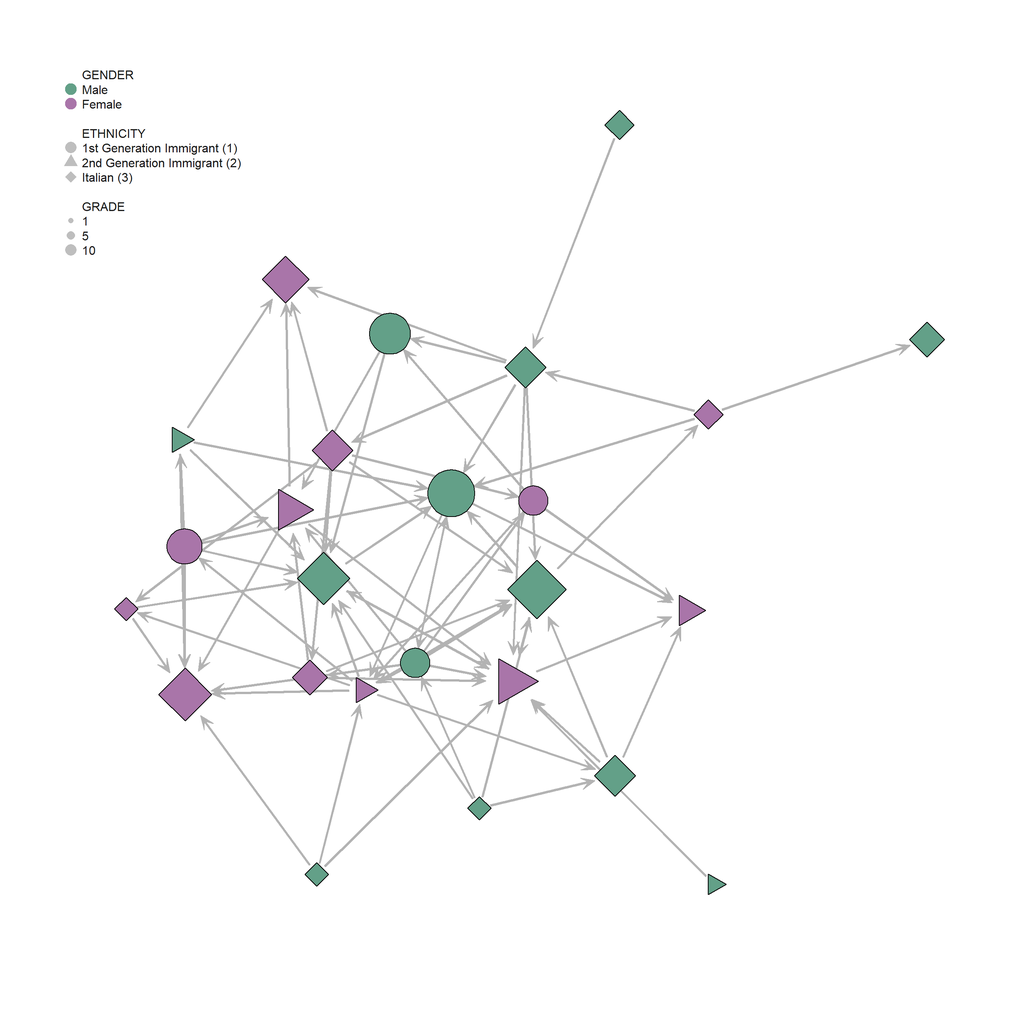

```r
# Prepare color vector for gender
genderVectorColor = c()
for (g in attributes_xlsx$Gender) {
  if (g == 1) {
    genderVectorColor = append(genderVectorColor, "#63A088")
  } else {
    genderVectorColor = append(genderVectorColor, "#A975A9")
  }
}

# Prepare color vector for ethnicity
ethnicityVectorColor = c()
for (e in attributes_xlsx$Ethnicity) {
  if (e == 1) {
    ethnicityVectorColor = append(ethnicityVectorColor, 50)
  } else if (e == 2) {
    ethnicityVectorColor = append(ethnicityVectorColor, 3)
  } else {
    ethnicityVectorColor = append(ethnicityVectorColor, 4)
  }
}

# Plot the network
gplot(bully_network,
      gmode = "digraph",

      # layout
      mode = "fruchtermanreingold",
      jitter = T,

      # ties
      edge.col = "grey70",

      # nodes
      vertex.col = genderVectorColor,
      vertex.cex = attributes_xlsx$Grade/5,
      vertex.sides = ethnicityVectorColor,

      # arrow
      arrowhead.cex = 0.5,

      # labels
      displaylabels = F,
      label.pos = 1,
      label.cex = 1
      )

# Customize the legend
legend(
  "topleft",

  legend = c(
    "GENDER",
    "Male",
    "Female",
    " ",
    "ETHNICITY",
    "1st Generation Immigrant (1)",
    "2nd Generation Immigrant (2)",
    "Italian (3)",
    " ",
    "GRADE",
    "1",
    "5",
    "10"),

  col = c(
    "white",
    "#63A088",
    "#A975A9",
    "white",
    "white",
    "gray",
    "gray",
    "gray",
    "white",
    "white",
    "gray",
    "gray",
    "gray"
    ),

  bty = "n",
  pch = c(19,19,19,19, 19,16,17,18,19, 16,16,16,16),
  pt.cex = c(0,2.1,2.1,0, 0,2.1,1.9,2.1,0, 2.1,1,1.55,2.1),
  cex = 1,
  text.col = "grey10",
  horiz = F,
  inset = c(0)
  )
```

## 2. Centrality

#### **Point 2.1**

##### *Calculate **indegree** and **outdegree** **centrality** for each node and interpret your results.*

- Provide the indegree and outdegree centrality score for each node.
- Who is the most central when it comes to indegree?
  - Provide details of the meaning of the value (taking into account that the network is “who do you bully?”).
  - Make sure to discuss the reference points for the indegree measure. How does it compare to the theoretical minimum and maximum value?
- Who is the most central when it comes to outdegree?
  - Provide details of the meaning of the value (taking into account that the network is “who do you bully?”).
  - Make sure to discuss the reference points for the outdegree measure. How does it compare to the theoretical minimum and maximum value?

##### *Provide the indegree and outdegree centrality score for each node.*

When dealing with a direct network we can calculate outdegree and indegree centrality:

- **outdegree centrality** refers to the total number of *outgoing* ties for each node
- **indegree centrality** refers to the total number of *incoming* ties for each node

If, on the other hand, we were dealing with an indirect network, we would have only one measure of degree centrality.

We can calculate indegree and outdegree by counting incoming and outgoing ties for each node in the network. In R we can use the function `sna::degree`.

```r
# Set nodes name as id
id = rownames(bully_xlsx)

# Calculate indegree
indegree = sna::degree(bully_network, gmode = "digraph", cmode = "indegree")
# Calculate outdegree
outdegree = sna::degree(bully_network, gmode = "digraph", cmode = "outdegree")
# Calculate freeman centrality
freeman = sna::degree(bully_network, gmode = "digraph", cmode = "freeman")


# Create a dataset to store these information
degree_df = data.frame(id, indegree, outdegree, freeman)
degree_df
```

| id | indegree | outdegree | freeman |
| --- | --- | --- | --- |
| Alessandro | 0 | 4 | 4 |
| Andrea | 7 | 3 | 10 |
| Angela | 4 | 6 | 10 |
| Angelo | 2 | 6 | 8 |
| Anna | 1 | 5 | 6 |
| Aurora | 1 | 6 | 7 |
| Flavio | 1 | 0 | 1 |
| Francesco | 2 | 8 | 10 |
| Gianna | 8 | 0 | 8 |
| Giovanni | 2 | 3 | 5 |

[output cut: 15 more lines]

##### *Who is the most central when it comes to indegree?*

```r
# Get the maximum indegree row
degree_df[degree_df$indegree == max(degree_df$indegree),]
```

|  | id | indegree | outdegree | freeman |
| --- | --- | --- | --- | --- |
| 21 | Sara | 9 | 2 | 11 |

Sara is the most central actor with respect to indegree, with a value of 9.

##### *Provide details of the meaning of the value (taking into account that the network is “who do you bully?”)*

Since the network boundaries are represented by the question “who do you bully?” and the indegree value is the number of incoming ties, we can say that **Sara** is the most bullied person in the network.

##### *Make sure to discuss the reference points for the indegree measure. How does it compare to the theoretical minimum and maximum value?*

The minimum possible value for Indegree is $0$, i.e. the situation in which a node is not bullied by any other node. The maximum value is instead $n - 1$ (in this case $25 - 1 = 24$), meaning that a node is bullied by all other nodes except itself.

We can normalize the obtained Indegree value to get the proportion of people bullying Sara, from a scale that goes from $0$ to $1$.

$$NormalizedIndegree = \frac{Indegree}{n-1} = \frac{9}{25-1} = 0.375$$

From the *NormalizedIndegree* value we can see that Sara is bullied by more than $\displaystyle \frac{1}{3}$ of the people in the network.

##### *Who is the most central when it comes to outdegree?*

```r
# Get the maximum outdegree row
degree_df[degree_df$outdegree == max(degree_df$outdegree),]
```

|  | id | indegree | outdegree | freeman |
| --- | --- | --- | --- | --- |
| 8 | Francesco | 2 | 8 | 10 |

Francesco is the most central actor with respect to outdegree, with a value of 8.

##### *Provide details of the meaning of the value (taking into account that the network is “who do you bully?”).*

In this case the measure refers to the number of people in the network that **Francesco** says he bullies.

##### *Make sure to discuss the reference points for the outdegree measure. How does it compare to the theoretical minimum and maximum value?*

Again, the minimum value is $0$, in the hypothetical situation where a node does not bully anyone, and the maximum is $n - 1$, in the situation where an actor bullies all other nodes except himself.

We find the normalized value dividing the outdegree by the maximum possible outdegree:

$$NormalizedOutdegree = \frac{Outdegree}{n-1} = \frac{8}{25-1} = 0.333$$
Francesco bullies $\displaystyle \frac{1}{3}$ of the network.

We show the position and attributes of Sara and Francesco in the net by highlighting them.

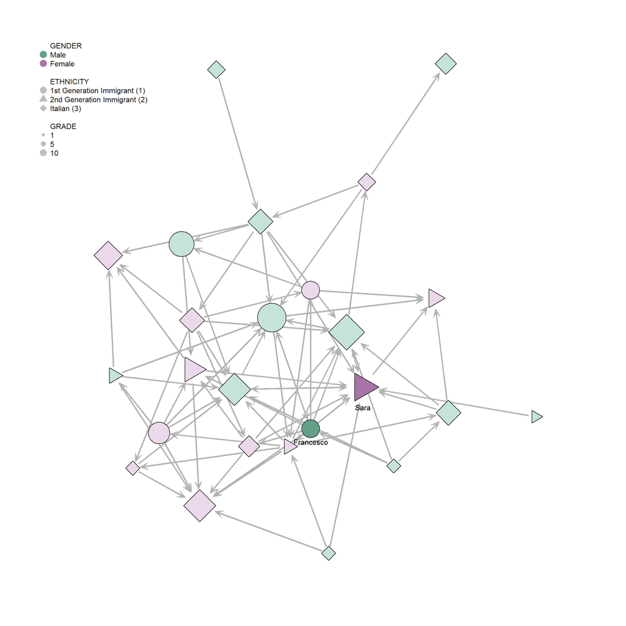

```r
# Prepare color vector for gender
genderVectorColor = c()
for (g in attributes_xlsx$Gender) {
  if (g == 1) {
    genderVectorColor = append(genderVectorColor, "#c5e3d7")
  } else {
    genderVectorColor = append(genderVectorColor, "#ebd8eb")
  }
}

# Set darker color for Sara and Francesco nodes
genderVectorColor[which(degree_df$id == "Sara")] = "#A975A9"
genderVectorColor[which(degree_df$id == "Francesco")] = "#63A088"

# Prepare color vector for ethnicity
ethnicityVectorColor = c()
for (e in attributes_xlsx$Ethnicity) {
  if (e == 1) {
    ethnicityVectorColor = append(ethnicityVectorColor, 50)
  } else if (e == 2) {
    ethnicityVectorColor = append(ethnicityVectorColor, 3)
  } else {
    ethnicityVectorColor = append(ethnicityVectorColor, 4)
  }
}

# Prepare label vector for Francesco and Sara's nodes.
label_vector = c("","","","","","","","Francesco","","","","","","","","","","","","","Sara","","","","")

# Plot the network
gplot(bully_network,
      gmode = "digraph",

      # layout
      mode = "fruchtermanreingold",
      jitter = T,

      # ties
      edge.col = "grey70",

      # nodes
      vertex.col = genderVectorColor,
      vertex.cex = attributes_xlsx$Grade/5,
      vertex.sides = ethnicityVectorColor,

      # arrow
      arrowhead.cex = 0.5,

      # labels
      label=label_vector,
      label.pos = 1,
      label.cex = 1
      )

# Customize the legend
legend(
  "topleft",

  legend = c(
    "GENDER",
    "Male",
    "Female",
    " ",
    "ETHNICITY",
    "1st Generation Immigrant (1)",
    "2nd Generation Immigrant (2)",
    "Italian (3)",
    " ",
    "GRADE",
    "1",
    "5",
    "10"),

  col = c(
    "white",
    "#63A088",
    "#A975A9",
    "white",
    "white",
    "gray",
    "gray",
    "gray",
    "white",
    "white",
    "gray",
    "gray",
    "gray"
    ),

  bty = "n",
  pch = c(19,19,19,19, 19,16,17,18,19, 16,16,16,16),
  pt.cex = c(0,2.1,2.1,0, 0,2.1,1.9,2.1,0, 2.1,1,1.55,2.1),
  cex = 1,
  text.col = "grey10",
  horiz = F,
  inset = c(0)
  )
```

The last graph highlights that Sara has high marks (9), while Francesco has lower marks (5). Francesco is a first generation immigrant, while Sara is a second generation immigrant.

#### **Point 2.2**

##### Let’s assume we hypothesize that the grade of students might be impacted by how many others they are being bullied by. Calculate the correlation between the indegree and the grade of the kid.

- What is the correlation value?
- What does it mean substantively?
- Provide the R script of how you obtain the results.

##### *What is the correlation value?*

```r
# Add indegree and outdegree values to our dataset
merge_df = merge(attributes_xlsx, degree_df, by.x = "ID", by.y = "id")
merge_df
```

| ID | Gender | Grade | Ethnicity | indegree | outdegree | freeman |
| --- | --- | --- | --- | --- | --- | --- |
| Alessandro | 1 | 4 | 3 | 0 | 4 | 4 |
| Andrea | 1 | 8 | 1 | 7 | 3 | 10 |
| Angela | 0 | 5 | 2 | 4 | 6 | 10 |
| Angelo | 1 | 7 | 3 | 2 | 6 | 8 |
| Anna | 0 | 6 | 1 | 1 | 5 | 6 |
| Aurora | 0 | 7 | 3 | 1 | 6 | 7 |
| Flavio | 1 | 6 | 3 | 1 | 0 | 1 |
| Francesco | 1 | 5 | 1 | 2 | 8 | 10 |
| Gianna | 0 | 9 | 3 | 8 | 0 | 8 |
| Giovanni | 1 | 7 | 3 | 2 | 3 | 5 |

[output cut: 15 more lines]

```r
# Calculate correlation
cor.test(merge_df$Grade, merge_df$indegree)
```

```
##
##  Pearson's product-moment correlation
##
## data:  merge_df$Grade and merge_df$indegree
## t = 7.0955, df = 23, p-value = 3.151e-07
## alternative hypothesis: true correlation is not equal to 0
## 95 percent confidence interval:
##  0.6442938 0.9218508
## sample estimates:
##       cor
## 0.8285039
```

The correlation value between the *grade of students* and how many others they are being bullied by (*indegree*) is $0.8285039$.

##### *What does it mean substantively?*

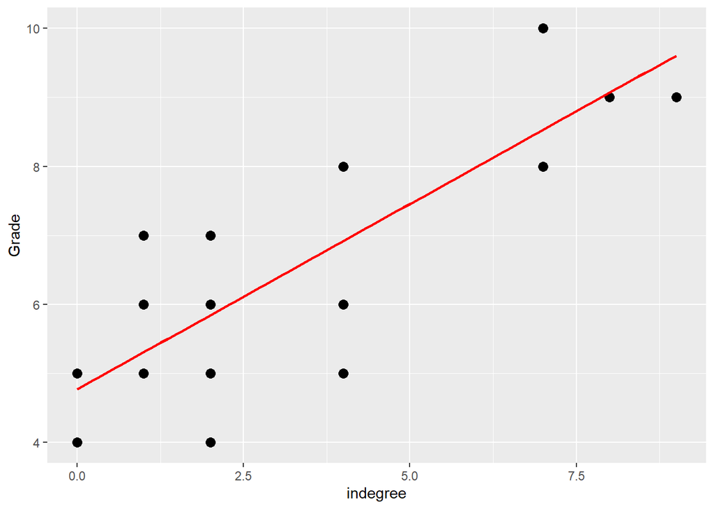

```r
library(ggplot2)

# Plot the indegree-grade scatterplot
ggplot(merge_df, aes(x=indegree, y=Grade)) +
    geom_point(size=3) +
    # add regression line
    geom_smooth(method=lm , color="red", se=FALSE)
```

Looking at the results we can say that there is a high correlation between the grade and the indegree (how much a person is bullied). It is possible to see that this result is statistically significant given its low p-value ($3.151 \cdot 10^{-7}$). Moreover, we can derive that a person with high grades tends to be bullied more, as we saw in Sara’s example and in the scatterplot above.

Out of curiosity, we also inspect the correlation between the outdegree and the grades.

```r
# Calculate correlation
cor.test(merge_df$Grade, merge_df$outdegree)
```

```
##
##  Pearson's product-moment correlation
##
## data:  merge_df$Grade and merge_df$outdegree
## t = -1.0014, df = 23, p-value = 0.3271
## alternative hypothesis: true correlation is not equal to 0
## 95 percent confidence interval:
##  -0.5547203  0.2074999
## sample estimates:
##        cor
## -0.2043888
```

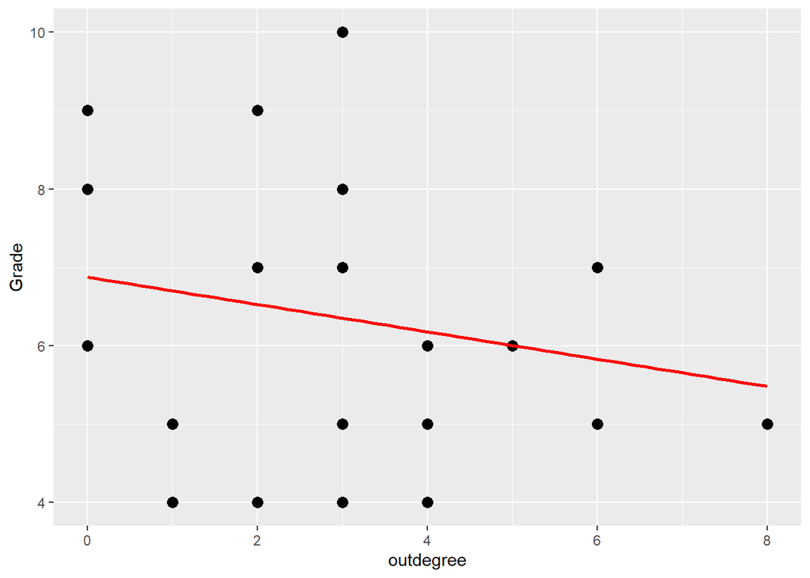

```r
# Plot the indegree-grade scatterplot using ggplot2
ggplot(merge_df, aes(x=outdegree, y=Grade)) +
    geom_point(size=3) +
    geom_smooth(method=lm , color="red", se=FALSE)
```

In this case, we have a low negative correlation ($-0.20$) and a quite high p-value, thus the result cannot be considered as statistically significant.

#### **Point 2.3**

##### Finally, perform a significance test using a permutation-based approach for the correlation as discussed in class.

- What does the significance test do and what do you conclude?
- Add the R script of how you obtained the results.

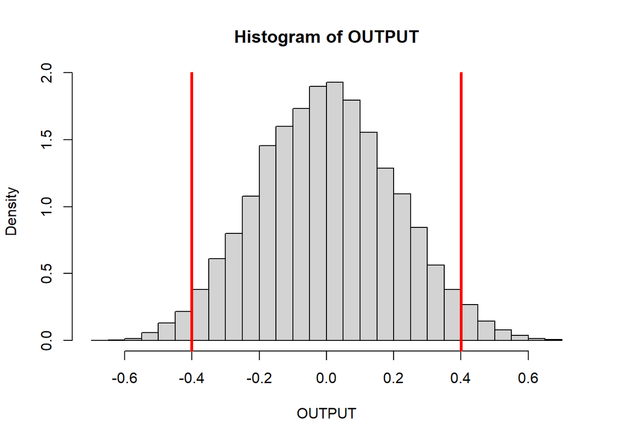

```r
# Set seed in order to get a reproducible random result
set.seed(1)

# Create the number of permutations value (to be easily changed)
n_permutation = 20000

# Build a permutation based approach to test for significance
OUTPUT = matrix(NA, n_permutation,1)
for (k in c(1:n_permutation))
{
  grade_PERM = sample(merge_df$Grade) # grade permutation
  OUTPUT[k,1] = cor(merge_df$indegree, grade_PERM)
}

# Plot the results as an histrogram
hist(OUTPUT, nclass=30, prob=T)
# add upper bounder
abline(v = mean(OUTPUT) + sd(OUTPUT)*1.96, col = "red", lwd = 3) # 0.4012781
# add lower bounder
abline(v = mean(OUTPUT) - sd(OUTPUT)*1.96, col = "red", lwd = 3) # -0.4001141
```

```r
# Assign the real value of correlation to a variable
corRealValue = cor(merge_df$Grade, merge_df$indegree)

message(
  "% of times that the correlation were >= the found correlation value: ",
  sum(OUTPUT >= +abs(corRealValue))/n_permutation, "\n",
  "% of times that the correlation were < the found correlation value: ",
  sum(OUTPUT <= -abs(corRealValue))/n_permutation, "\n",
  "% of times that the correlation were >= or < the found correlation value: ",
  sum(OUTPUT >= +abs(corRealValue))/n_permutation + sum(OUTPUT <= -abs(corRealValue))/n_permutation
  )
```

```
## % of times that the correlation were >= the found correlation value: 0
## % of times that the correlation were < the found correlation value: 0
## % of times that the correlation were >= or < the found correlation value: 0
```

A test of significance is a formal procedure for comparing observed data with a claim (also called a hypothesis), the truth of which is being assessed. Tests for statistical significance indicate whether observed differences between assessment results are due to chance, which should be ignored because they lead to incorrect assumptions, or whether they are due to significant patterns.

In none of the permutations we obtain a value greater or less than the true indegree-grade correlation value. This confirms what we expected since the p-value is very low and it is therefore highly unlikely that there would be such a correlation by chance. Moreover, as we have seen in the previous scatterplot, there seem to be no outliers able to affect the correlation. It might also be noted that the histogram seems to have a normal shape, however this may not be the case, since it is the p-value itself that is built on the assumption of normality.

## 3. Centralization and reciprocity

#### **Point 3.1**

##### Calculate the *indegree* and *outdegree* **centralization** for this network using the approach discussed in class and interpret.

- Make sure to show *how* you came to these answers.
- What do you conclude substantively (taking into account that the network is “who do you bully?”)?
- Make sure to discuss the reference points for the measure. What is the minimum and maximum value?

```r
# Obtain maximum value of indegree and outdegree
max_indegree = degree_df[degree_df$indegree == max(indegree),]$indegree
max_outdegree = degree_df[degree_df$outdegree == max(outdegree),]$outdegree

# Add columns of indegree and outdegree centralization to df
degree_df$indegree_centralization = max_indegree - degree_df$indegree
degree_df$outdegree_centralization = max_outdegree - degree_df$outdegree

degree_df
```

| id | indegree | outdegree | freeman | indegree_centralization | outdegree_centralization |
| --- | --- | --- | --- | --- | --- |
| Alessandro | 0 | 4 | 4 | 9 | 4 |
| Andrea | 7 | 3 | 10 | 2 | 5 |
| Angela | 4 | 6 | 10 | 5 | 2 |
| Angelo | 2 | 6 | 8 | 7 | 2 |
| Anna | 1 | 5 | 6 | 8 | 3 |
| Aurora | 1 | 6 | 7 | 8 | 2 |
| Flavio | 1 | 0 | 1 | 8 | 8 |
| Francesco | 2 | 8 | 10 | 7 | 0 |
| Gianna | 8 | 0 | 8 | 1 | 8 |
| Giovanni | 2 | 3 | 5 | 7 | 5 |

[output cut: 15 more lines]

```r
# Obtain the values of indegree and outdegree centralization for the network
indegree_centralization_network = sum(degree_df$indegree_centralization)
outdegree_centralization_network = sum(degree_df$outdegree_centralization)

# Normalize the results

# obtain total number of nodes
n = nrow(degree_df)

# calculate maximum possible value of indegree/outdegree centralization for our network
max_indegree_centralization = (n-1)^2
max_outdegree_centralization = (n-1)^2

# obtain normalized values
normalized_indegree_centralization_network = indegree_centralization_network/max_indegree_centralization
normalized_outdegree_centralization_network = outdegree_centralization_network/max_outdegree_centralization

# Show results
message(
  "Indegree centralization: ", indegree_centralization_network, "\n",
  "Maximum indegree centralization: ", max_indegree_centralization, "\n",
  "Normalized indegree centralization: ", round(normalized_indegree_centralization_network, 2), "\n\n",

  "Outdegree centralization: ", outdegree_centralization_network, "\n",
  "Maximum outdegree centralization: ", max_outdegree_centralization, "\n",
  "Normalized outdegree centralization: ", round(normalized_outdegree_centralization_network, 2), "\n"
  )
```

```
## Indegree centralization: 151
## Maximum indegree centralization: 576
## Normalized indegree centralization: 0.26
##
## Outdegree centralization: 126
## Maximum outdegree centralization: 576
## Normalized outdegree centralization: 0.22
```

The minimum value of indegree and outdegree centralization that can be observed in a network is $0$. On the other hand the maximum value is, as we have calculated, equal to: $(n-1)^2$.

As can be seen, the normalized values of outdegree and indegree centralization are not very high, which means that in both cases there is no very central node. This implies that no one is bullied by the majority of the network or bullies most of the classmates.

#### **Point 3.2**

##### Calculate the arc-based reciprocity index for this network and interpret.

- Make sure to show *how* you came to this answer.
- What do you conclude substantively (taking into account that the network is “who do you bully?”)?
- Make sure to discuss the reference points for the measure. What is the minimum, expected and maximum value?

```r
# Get the total number of mutual, asymmetric and null dyads
sna::dyad.census(bully_matrix)
```

```
##      Mut Asym Null
## [1,]   2   70  228
```

```r
# Arc-based reciprocity
sna::grecip(bully_matrix, measure = "edgewise")
```

```
##        Mut
## 0.05405405
```

```r
# With IGRAPH
library(igraph)

# Convert in adjency matrix for igraph function
adj_matrix = graph_from_adjacency_matrix(bully_matrix, mode = c("directed"), diag = F)

# Arc-based reciprocity
igraph::reciprocity(adj_matrix)
```

```
## [1] 0.05405405
```

`sna::grecip()` and `igraph::reciprocity` use the following formula to obtain the index reciprocity value:

$$Index(reciprocity) = \frac{2\cdot Mutual}{2\cdot Mutual + Asymmetric} = \frac{2\cdot 2}{2\cdot 2 + 70} = 0.0541$$

The minimum possible value is $0$, which is anti-reciprocity:
$$\frac{2 \cdot M}{2 \cdot M+A}=\frac{2 \cdot 0}{2 \cdot 0+A}=\frac{0}{A}=0$$

It occurs when there are no reciprocal dyads.

The maximum possible value is $1$, which is perfect reciprocation:

$$\frac{2 \cdot M}{2 \cdot M+A}=\frac{2 \cdot M}{2 \cdot M+0}=\frac{2 \cdot M}{2 \cdot M}=1$$

It occurs when there are only reciprocal dyads and no asymmetrical dyads in the network.

As it can be seen, the index for our network is very close to the minimum value. By calculating indegree and outdegree, bullies can also be bullied (e.g. Angela: indegree = 4, outdegree = 6), but usually the same actors are not involved. In our network it is therefore rare for nodes to bully each other. This result seems to be realistic since usually the “who do you bully” relationship is typically one-sided.